# Biclusters 02 – making sense of biclusters

Author

Tim

Published

April 24, 2026

Load and prepare fit, split into biclusters, assign rownames etc.

```r
library(dplyr)
library(data.table)
library(SingleCellExperiment)
library(Matrix)
library(lemur)
library(tidyverse)
library(Polychrome)
library(scico)
library(patchwork)
library(pheatmap)
library(fgsea)
library(msigdbr)
library("progressr")

# Choose folders for data and results etc.
folder_data <- "/Users/herbermann/code/data/coculture/"
file_name <- "coculture_effect_in_AML_5000"
wd <- "/Users/herbermann/code/lemur_biclusters"
cache_dir <- file.path(wd, "rds")

set.seed(42)

sce_all <- readRDS(paste0(folder_data, "sce_object_", file_name, ".RDS"))

table_bicluster <- readRDS(file.path(cache_dir, "bicluster_gsea_table.RDS"))
nes_mat <- readRDS(file.path(cache_dir, "bicluster_gsea_nes_mat.RDS"))
table_pseudobulk <- readRDS(file.path(cache_dir, "pseudobulk_gsea_table.RDS"))

# Let us also get all the bicluster details.
filename <- file.path(cache_dir, "fit_nmf.RDS")
nmf_fit <- readRDS(filename)

biclusters <- nmf_fit$biclusters
null_h <- nmf_fit$null_h
null_w_pos <- nmf_fit$null_w_pos
null_w_neg <- nmf_fit$null_w_neg

W <- biclusters@w
H <- biclusters@h

n_genes <- nrow(W)/2
W_pos <- W[1:n_genes, ]
W_neg  <- W[(n_genes+1):nrow(W), ]

fit <- readRDS(file.path(cache_dir, "lemur_essi_fit.rds"))
de_matrix <- as.matrix(assay(fit$training_data, "DE"))

rownames(W_pos) <- rownames(de_matrix)
rownames(W_neg) <- rownames(de_matrix)

# Getting cell level labels and label bicluster members
celltype_map <- setNames(sce_all$clusters_renamed, colnames(sce_all))
patient_map <- setNames(sce_all$individual, colnames(sce_all))


# Make all assignments of cell membership to biclusters
null_h <- null_h[3,]
null_w_pos <- null_w_pos[3,]
null_w_neg <- null_w_neg[3,]

n_bic <- nrow(H)

bic_cells <- lapply(1:n_bic, function(i){
  H[i,] > null_h[i]
})

bic_up <- lapply(1:n_bic, function(i){
  W_pos[,i] > null_w_pos[i]
})

bic_down <- lapply(1:n_bic, function(i){
  W_neg[,i] > null_w_neg[i]
})

bic_genes <- Map(function(up, down) up | down, bic_up, bic_down)
```

```r
jaccard_with_logic <- function(A, B) {
  stopifnot(length(A) == length(B))
  denom <- sum(A | B)
  if (denom == 0) return(NA_real_)
  sum(A & B) / denom
}

n_bic <- length(bic_cells)

jaccard_cells <- matrix(
  NA_real_,
  nrow = n_bic,
  ncol = n_bic,
  dimnames = list(paste0("Bic_", seq_len(n_bic)),
                  paste0("Bic_", seq_len(n_bic)))
)

for (i in seq_len(n_bic)) {
  for (j in seq_len(n_bic)) {
    jaccard_cells[i, j] <- jaccard_with_logic(bic_cells[[i]], bic_cells[[j]])
  }
}

n_bic <- length(bic_genes)

jaccard_genes <- matrix(
  NA_real_,
  nrow = n_bic,
  ncol = n_bic,
  dimnames = list(paste0("BIC", seq_len(n_bic)),
                  paste0("BIC", seq_len(n_bic)))
)

for (i in seq_len(n_bic)) {
  for (j in seq_len(n_bic)) {
    jaccard_genes[i, j] <- jaccard_with_logic(bic_genes[[i]], bic_genes[[j]])
  }
}
```

Jaccard overlaps of genes (up & down) and cells of biclusters.

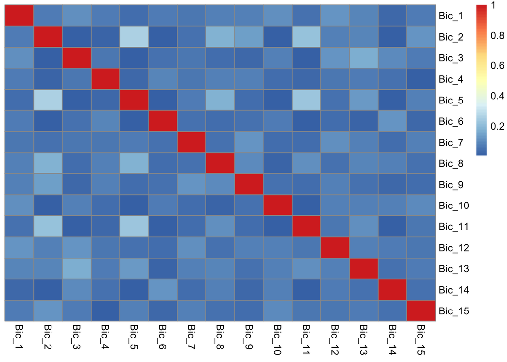

```r
pheatmap(
  jaccard_cells,
  scale = "none",
  cluster_rows = FALSE,
  cluster_cols = FALSE
)
```

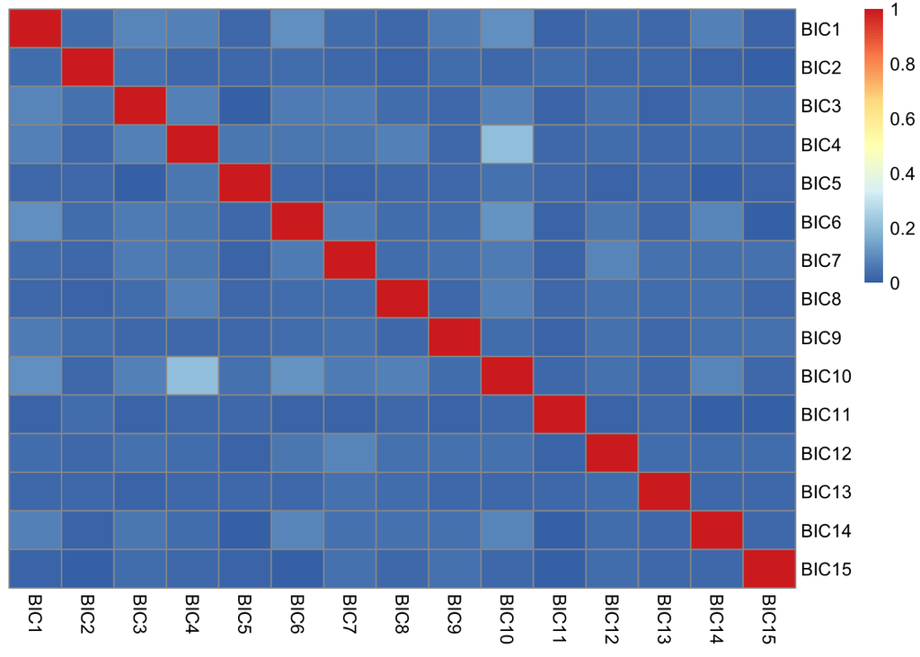

```r
pheatmap(
  jaccard_genes,
  scale = "none",
  cluster_rows = FALSE,
  cluster_cols = FALSE
)
```

Having fit $k = 15$ (note the early stopping!) biclusters, their biological meaning (and relevance) remains somewhat obscure. The idea is to bundle the coexpressed (or suppressed) genes in any bicluster into meaningful gene programmes. We do this with GSEA (fgsea package) on biclusters.

# GSEA

To perform GSEA on biclusters, we need a test statistic. We use a $t$-test on pseudobulks of bicluster vs. the rest. Gene pathways are assigend based on the HALLMARKS set. We perform the analysis for every bicluster that was found. This is not proper statistics yet, we should use an actual pseudobulking pipeline that is more rigorous, think DESeq2 or edgeR.

```r
score_bicluster <- function(de_matrix, membership, standardize = TRUE, eps = 1e-8) {
  stopifnot(ncol(de_matrix) == length(membership))

  in_idx  <- which(membership)
  out_idx <- which(!membership)

  if (length(in_idx) == 0) stop("membership contains no selected cells.")
  if (length(out_idx) == 0) stop("membership selects all cells; no background remains.")

  x_in  <- de_matrix[, in_idx, drop = FALSE]
  x_out <- de_matrix[, out_idx, drop = FALSE]

  score <- rowMeans(x_in, na.rm = TRUE) - rowMeans(x_out, na.rm = TRUE)

  if (standardize) {
    s_in  <- matrixStats::rowSds(as.matrix(x_in),  na.rm = TRUE)
    s_out <- matrixStats::rowSds(as.matrix(x_out), na.rm = TRUE)
    pooled <- sqrt((s_in^2 + s_out^2) / 2)
    score <- score / (pooled + eps)
  }

  names(score) <- rownames(de_matrix)
  sort(score, decreasing = TRUE)
}



msig <- msigdbr(species = "Homo sapiens", category = "H")
pathways <- split(msig$gene_symbol, msig$gs_name)

scores_list <- lapply(1:ncol(W_pos),
  function(i) {
    score_bicluster(de_matrix, (H[i,] > null_h[i]))
})

res_list <- lapply(1:ncol(W_pos),
  function(i) {
    fgsea(pathways = pathways, stats = scores_list[[i]])
})

bic_names <- paste0("BIC", seq_along(res_list))
names(res_list) <- bic_names

all_pathways <- unique(unlist(lapply(res_list, function(x) x$pathway)))

nes_mat <- matrix(
  NA_real_,
  nrow = length(res_list),
  ncol = length(all_pathways),
  dimnames = list(bic_names, all_pathways)
)

for (i in seq_along(res_list)) {
  res <- res_list[[i]]
  nes_mat[i, res$pathway] <- res$NES
}
```

# Results

Heatmaps for the NES score for biclusters and genes, as well as correlation thereof.

We summarize a table with all significant ($p_\mathrm{adj}<0.05$) pathways identified in biclusters. It is evident how biclusters load multiple programmes (up- or down NES). At first sight, biclusters are distinct in the programmes they load, although, pairwise significant overlap is possible. This really highlights the multiple membership of genes (= pathways) over biclusters.

We should think of biclusters as characterised by a number of meta-genes (=gene programmes) and meta-cells (cell space cluster part), that are potentially correlated.

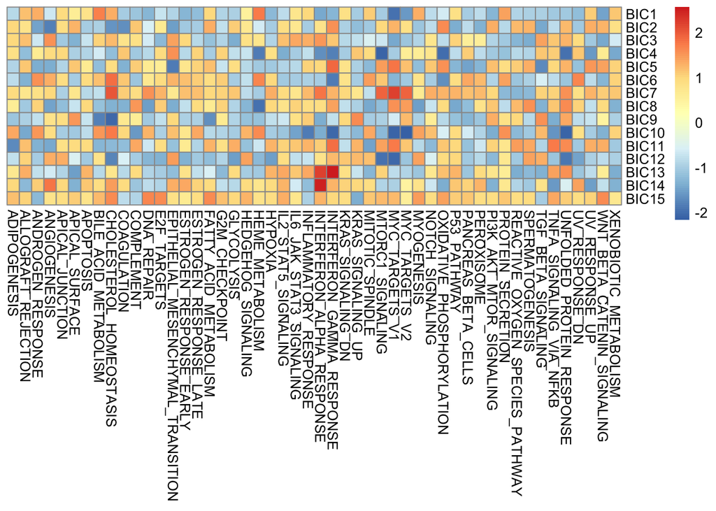

```r
colnames(nes_mat) <- sub("^HALLMARK_", "", colnames(nes_mat))

pheatmap(
  nes_mat,
  scale = "none",
  cluster_rows = FALSE,
  cluster_cols = FALSE
)
```

Correlation and partial overlap becomes particularly evident if we plot the correlation matrix of biclusters.

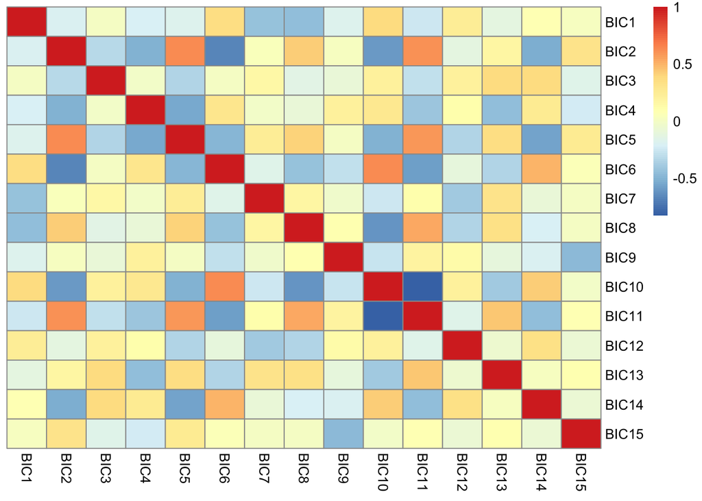

```r
cor_mat <- cor(t(nes_mat))
pheatmap(
  cor_mat,
  scale = "none",
  cluster_rows = FALSE,
  cluster_cols = FALSE
)
```

```r
# collect in a table we write to file later.
table <- do.call(
  rbind,
  lapply(seq_along(res_list), function(i) {
    g <- res_list[[i]]

    if (is.null(g) || nrow(g) == 0) return(NULL)

    g_sig <- g[g$padj < 0.05, ]
    if (nrow(g_sig) == 0) return(NULL)

    data.frame(
      bicluster = i,
      pathway = g_sig$pathway,
      NES = g_sig$NES,
      padj = g_sig$padj,
      pval = g_sig$pval,
      ES = g_sig$ES,
      size = g_sig$size,
      stringsAsFactors = FALSE
    )
  })
)

filename <- file.path(cache_dir, "bicluster_gsea_table.RDS")
saveRDS(table, filename)

filename <- file.path(cache_dir, "bicluster_gsea_nes_mat.RDS")
saveRDS(nes_mat, filename)
```

# Using meta data

So far, we found these sets of meta-genes and meta-cells without ever referring to additional meta data that is available. Let us do that.

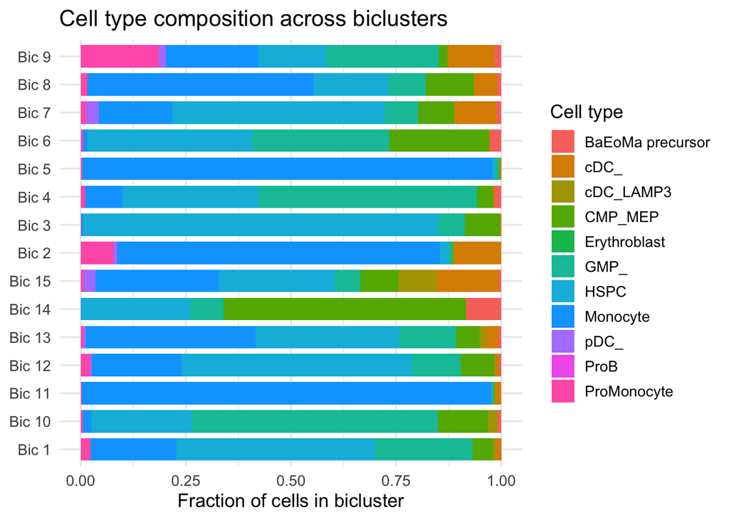

```r
#Investigate connection of biclusters to known annotations
# --- align all objects to the same cells ---
common_cells <- Reduce(intersect, c(
  list(names(celltype_map), names(patient_map)),
  lapply(bic_cells, names)
))

celltype_map2 <- celltype_map[common_cells]
patient_map2   <- patient_map[common_cells]
bic_cells2     <- lapply(bic_cells, function(x) x[common_cells])

# --- cell type composition within each bicluster ---
bic_celltypes <- lapply(seq_along(bic_cells2), function(i) {
  celltype_map2[bic_cells2[[i]]]
})

plot_df <- bind_rows(lapply(seq_along(bic_celltypes), function(i) {
  ct <- bic_celltypes[[i]]

  df <- as.data.frame(table(ct))
  colnames(df) <- c("celltype", "n")
  df$bic <- paste0("Bic ", i)
  df
})) %>%
  filter(!is.na(celltype)) %>%
  group_by(bic) %>%
  mutate(prop = n / sum(n)) %>%
  ungroup()

ggplot(plot_df, aes(x = bic, y = prop, fill = celltype)) +
  geom_col(width = 0.8) +
  coord_flip() +
  labs(
    x = NULL,
    y = "Fraction of cells in bicluster",
    fill = "Cell type",
    title = "Cell type composition across biclusters"
  ) +
  theme_minimal(base_size = 13)
```

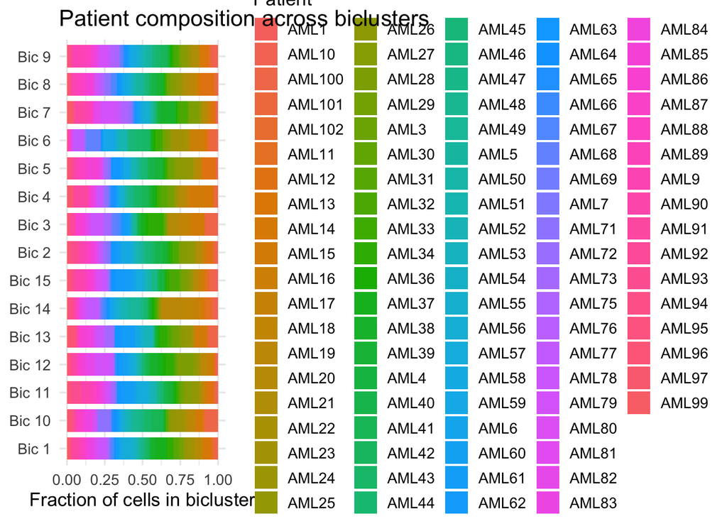

```r
# --- optional: patient composition within each bicluster ---
bic_patient <- lapply(seq_along(bic_cells2), function(i) {
  patient_map2[bic_cells2[[i]]]
})

plot_df_patient <- bind_rows(lapply(seq_along(bic_patient), function(i) {
  df <- as.data.frame(table(patient = bic_patient[[i]]))
  colnames(df) <- c("patient", "n")
  df$bic <- paste0("Bic ", i)
  df
})) %>%
  filter(!is.na(patient)) %>%
  group_by(bic) %>%
  mutate(prop = n / sum(n)) %>%
  ungroup()

ggplot(plot_df_patient, aes(x = bic, y = prop, fill = patient)) +
  geom_col(width = 0.8) +
  coord_flip() +
  labs(
    x = NULL,
    y = "Fraction of cells in bicluster",
    fill = "Patient",
    title = "Patient composition across biclusters"
  ) +
  theme_minimal(base_size = 13)
```

While biclusters vary in cell- and patient composition, there is no strong association of certain bicluster patient labels. This might be encouraging, as biclusters do identify gene programmes, and therefore, these appear to be programmes orthogonal to patients to some extend. However, patient may have unique sets of programmes in response to a condition contrast. A potentially stronger association with cell types is expected. Again, since we have not fed any meta data into the problem until now, any labelling into biclusters and programmes is ignorant about these discrete categories. However, a certain level of alignment seems biologically plausible to me.

We should stress here that the programmes we can identify are somewhat unique compared to traditional pseudobulk DE with labels! By construction, these are programmes responding to the condition contrast. Thus, a programme unaffected by that contrast is expected to drop out. We should expect that we can sublabel cell types e.g. by their condition response, which I expect in general to be different from other sublabels, cell states etc. Everything here derives meaning from being condition contrast sourced. This cannot be stressed enough!

# Big picture

Before looking into detail into certain biclusters, cell types and so on, it seems plausible to further compress the result at this point. We see that any given biclusters loads or suppresses multiple programmes. We can use PCA to identify meta-programmes (=sets of programmes) that play a role in characterising biclusters, and also, that should ease the problem of biological interpretation to some extent.

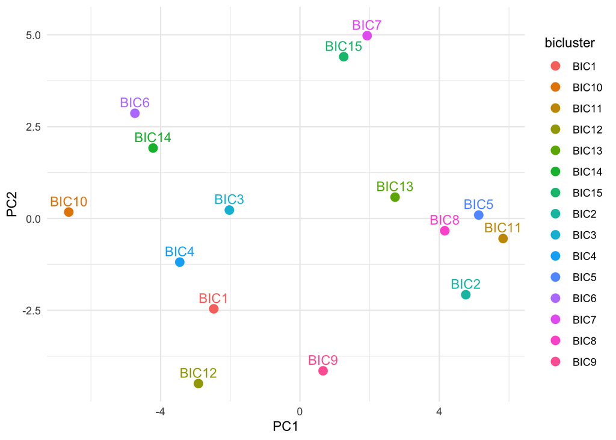

```r
pca_nes <- prcomp(nes_mat,center = TRUE, scale. = TRUE)

pca_nes$x |>
  as.data.frame() |>
  rownames_to_column("bicluster") |>
  ggplot(aes(PC1, PC2, color = bicluster, label = bicluster)) +
  geom_point(size = 3) +
  geom_text(nudge_y = 0.3, show.legend = FALSE) +
  theme_minimal()
```

```r
summary(pca_nes)
```

```
Importance of components:
                          PC1    PC2    PC3    PC4    PC5     PC6     PC7
Standard deviation     4.0382 2.7520 2.3909 2.2170 1.7847 1.74436 1.61948
Proportion of Variance 0.3261 0.1515 0.1143 0.0983 0.0637 0.06086 0.05245
Cumulative Proportion  0.3261 0.4776 0.5919 0.6902 0.7539 0.81479 0.86725
                           PC8     PC9    PC10    PC11    PC12   PC13    PC14
Standard deviation     1.29017 1.10542 0.99385 0.95692 0.86866 0.7746 0.70227
Proportion of Variance 0.03329 0.02444 0.01975 0.01831 0.01509 0.0120 0.00986
Cumulative Proportion  0.90054 0.92498 0.94473 0.96304 0.97814 0.9901 1.00000
                            PC15
Standard deviation     3.964e-16
Proportion of Variance 0.000e+00
Cumulative Proportion  1.000e+00
```

We see most variation is captured by PC1-PC4 (almost 70%), and perhaps some moderate contribtuion also from PC5-PC7. Those should correspond to interpretable combinations of programmes enriched over combinations of biclusters. As a heatmap, we see the loadings of programmes into the biclusters that they show a more coherent set of programmes. We can try to label these!

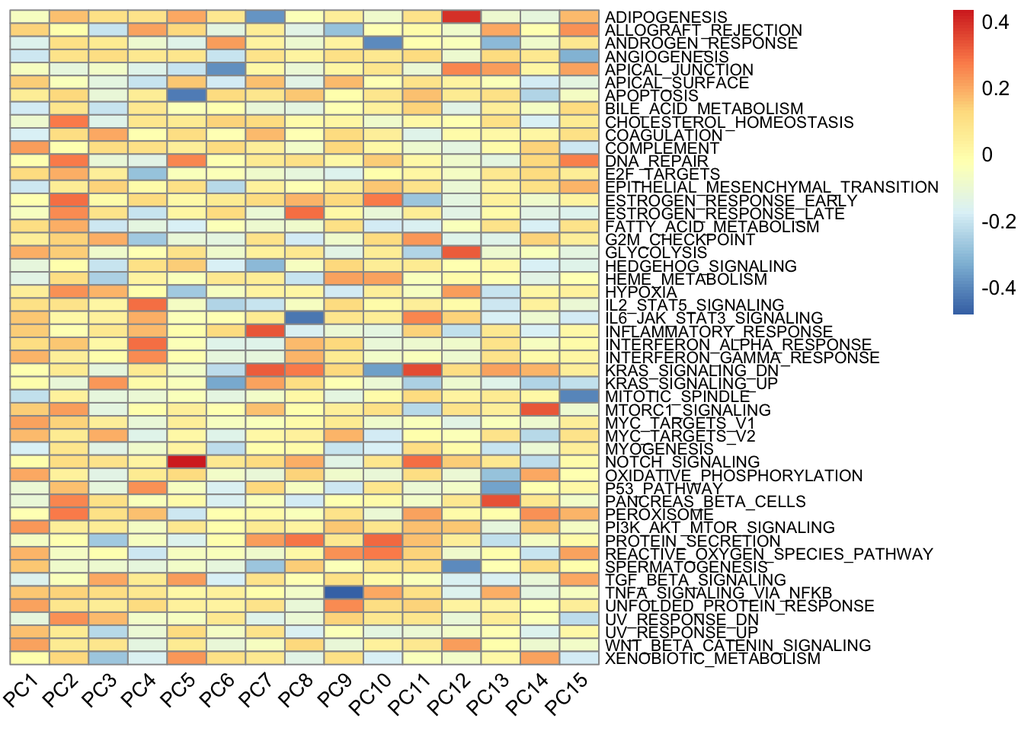

```r
pca_nes$rotation |>
  pheatmap(
    scale = 'none',
    cluster_rows = FALSE,
    cluster_cols = FALSE,
    angle_col = 45,
    fontsize_row = 8
  )
```

Taking the top entries for up- and downregulated programmes, let us label some PCA axes!

```r
pc1 <- pca_nes$rotation[,1]
pc1_pos <- paste(capture.output(head(sort(pc1, decreasing = TRUE), 12)), collapse = "<br>")
pc1_neg <- paste(capture.output(head(sort(pc1), 12)), collapse = "<br>")

pc2 <- pca_nes$rotation[,2]
pc2_pos <- paste(capture.output(head(sort(pc2, decreasing = TRUE), 12)), collapse = "<br>")
pc2_neg <- paste(capture.output(head(sort(pc2), 12)), collapse = "<br>")

pc3 <- pca_nes$rotation[,3]
pc3_pos <- paste(capture.output(head(sort(pc3, decreasing = TRUE), 12)), collapse = "<br>")
pc3_neg <- paste(capture.output(head(sort(pc3), 12)), collapse = "<br>")

pc4 <- pca_nes$rotation[,4]
pc4_pos <- paste(capture.output(head(sort(pc4, decreasing = TRUE), 12)), collapse = "<br>")
pc4_neg <- paste(capture.output(head(sort(pc4), 12)), collapse = "<br>")
```

Courtesy of ChatGPT/Claude, we assign some names to the PCs!

### PC1

Positive side (PC1 high) Key pathways: - PI3K / mTOR - MYC targets - glycolysis + OXPHOS - ROS / UPR / UV - IFNγ - complement - WNT

Grouped meaning:

1. Growth / proliferation (MYC, PI3K/mTOR)
2. Metabolic activation (glycolysis, OXPHOS)
3. Stress / adaptation (ROS, UPR, UV)
4. Immune signaling (IFNγ, complement)

Negative side (PC1 low)

Key pathways: - EMT / TGFβ - angiogenesis - coagulation - myogenesis - Hedgehog - bile acid metabolism - androgen response

Grouped meaning:

1. Differentiation / lineage programs (EMT, myogenesis, TGFβ)
2. Tissue / structural programs (angiogenesis, coagulation)
3. Specialized / terminal metabolism (bile acid)

*PC1 contrasts an activated, proliferative, metabolically engaged state with a differentiated, structural, lineage-associated state.*

### PC2

Positive side (PC2 high)

Key pathways:

- peroxisome, cholesterol, fatty acid metabolism
- mTOR, E2F
- DNA repair, UV response, hypoxia
- estrogen response (often metabolic/growth context)

Grouped meaning:

1. Lipid / metabolic activity (peroxisome, cholesterol, fatty acid)
2. biosynthesis / growth support (mTOR, E2F)
3. cell maintenance / repair (DNA repair, UV, hypoxia)

Negative side (PC2 low)

Key pathways:

- KRAS signaling
- TGFβ / Hedgehog
- inflammatory response, complement
- apical junction / surface
- protein secretion

Grouped meaning:

1. Signaling / communication (KRAS, TGFβ, Hedgehog)
2. Immune / interaction (inflammatory, complement)
3. Structural / polarity (apical junction/surface)

⸻

Define the contrast: *PC2 separates metabolically active / biosynthetic / repair-oriented states from signaling-driven, interaction-oriented, and structural states.*

and so on and so forth…

# Bonus: GATA2 and PC4

```r
gata2 <- de_matrix["GATA2",]
gata2 <- assay(sce_all, "logcounts")["GATA2",]

gata2_bic <- sapply(seq_along(bic_cells), function(i) {
  mean(gata2[bic_cells[[i]]], na.rm = TRUE)
})

names(gata2_bic) <- paste0("BIC", seq_along(bic_cells))

cor(gata2_bic, pca_nes$x)
```

```
            PC1       PC2        PC3       PC4        PC5       PC6       PC7
[1,] -0.2370694 0.3134371 -0.1875531 0.5890231 -0.1157131 0.1200998 0.1481435
           PC8       PC9      PC10       PC11      PC12      PC13      PC14
[1,] -0.193491 -0.308998 0.2552785 0.02901944 0.1954398 0.2961601 0.2980529
          PC15
[1,] 0.4115648
```

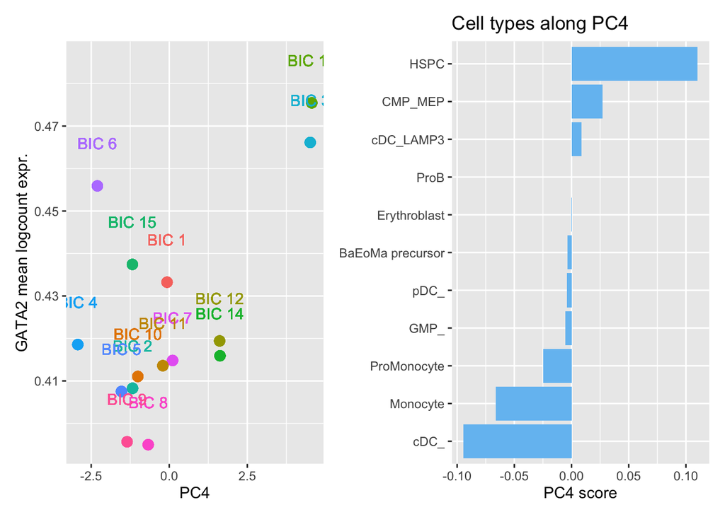

```r
pc1 <- pca_nes$x[,1]

plot_df <- seq_along(bic_celltypes) |>
  map(\(i) bic_celltypes[[i]] |>
      table() |>
      as.data.frame() |>
      setNames(c("celltype", "n")) |>
      mutate(bicluster = paste0("BIC ", i)) |>
      bind_cols(as_tibble_row(pca_nes$x[i, ]))
    ) |>
  list_rbind() |>
  filter(!is.na(celltype)) |>
  group_by(bicluster) |>
  mutate(prop = n / sum(n)) |>
  ungroup()

gata2_df <- tibble(bicluster = names(gata2_bic) |> sub("BIC", "BIC ", x = _),
                   gata2_bic = gata2_bic)

plot_df <- plot_df |> left_join(gata2_df, by = "bicluster")

plot1 <- plot_df |> ggplot(aes(PC4, gata2_bic, label=bicluster, color=bicluster)) +
  geom_point(aes(color=bicluster), size = 3, show.legend = FALSE) +
  labs(x = "PC4", y = "GATA2 mean logcount expr.") +
  geom_text(nudge_y = 0.01, show.legend = FALSE)



# compute a lweighted sum of PC1 loadings per cell type
# fraction of cells in BIC x PC1 loading of that BIC
celltype_pc4 <- aggregate(
  prop * pc4 ~ celltype,
  data = plot_df,
  FUN = sum
)

colnames(celltype_pc4)[2] <- "PC4_score"

plot2 <- ggplot(celltype_pc4, aes(x = reorder(celltype, PC4_score), y = PC4_score)) +
  geom_col(fill = "#75c0f2") +
  coord_flip() +
  labs(x = NULL, y = "PC4 score", title = "Cell types along PC4") +
  theme(legend.position = "none")

plot1 | plot2
```

# Selected cell types

### Monocytes

```r
bic2_cells  <- names(bic_cells[[2]])[bic_cells[[2]]]
bic5_cells  <- names(bic_cells[[5]])[bic_cells[[5]]]
bic11_cells <- names(bic_cells[[11]])[bic_cells[[11]]]

mono_cells <- names(celltype_map)[celltype_map == "Monocyte"]

mono_pathways <- table_pseudobulk |> filter(cell_type == "Monocyte") |>
    select(cell_type, pathway, NES, padj)

bic2_pathways <- table_bicluster |> filter(bicluster == 2) |>
    select(bicluster, pathway, NES, padj)
bic5_pathways <- table_bicluster |> filter(bicluster == 5) |>
    select(bicluster, pathway, NES, padj)
bic11_pathways <- table_bicluster |> filter(bicluster == 11) |>
    select(bicluster, pathway, NES, padj)

print("----BIC2----")
```

```
[1] "----BIC2----"
```

```r
print(bic2_pathways)
```

```
[1] bicluster pathway   NES       padj
<0 rows> (or 0-length row.names)
```

```r
print("----BIC5----")
```

```
[1] "----BIC5----"
```

```r
print(bic5_pathways)
```

```
  bicluster                                    pathway       NES         padj
1         5 HALLMARK_EPITHELIAL_MESENCHYMAL_TRANSITION -1.858832 0.0033782445
2         5         HALLMARK_INTERFERON_GAMMA_RESPONSE  1.892494 0.0003747715
3         5                    HALLMARK_MYC_TARGETS_V1  1.785823 0.0195153100
```

```r
print("----BIC11---")
```

```
[1] "----BIC11---"
```

```r
print(bic11_pathways)
```

```
  bicluster                            pathway      NES         padj
1        11 HALLMARK_INTERFERON_GAMMA_RESPONSE 1.836440 0.0004820326
2        11            HALLMARK_MYC_TARGETS_V1 1.759045 0.0162781569
3        11   HALLMARK_TNFA_SIGNALING_VIA_NFKB 1.754794 0.0015791427
```

```r
print("----MONO----")
```

```
[1] "----MONO----"
```

```r
print(mono_pathways)
```

```
           cell_type                            pathway      NES        padj
Monocyte.1  Monocyte HALLMARK_INTERFERON_GAMMA_RESPONSE 2.877119 0.001593761
Monocyte.2  Monocyte HALLMARK_INTERFERON_ALPHA_RESPONSE 2.630477 0.001593761
Monocyte.3  Monocyte   HALLMARK_TNFA_SIGNALING_VIA_NFKB 2.013505 0.001593761
Monocyte.4  Monocyte       HALLMARK_ALLOGRAFT_REJECTION 1.940079 0.001593761
Monocyte.5  Monocyte     HALLMARK_INFLAMMATORY_RESPONSE 1.873752 0.001593761
Monocyte.6  Monocyte   HALLMARK_IL6_JAK_STAT3_SIGNALING 1.819981 0.001593761
Monocyte.7  Monocyte                HALLMARK_COMPLEMENT 1.558951 0.025301751
```

### HSPC

```r
bic1_cells  <- names(bic_cells[[1]])[bic_cells[[1]]]
bic3_cells  <- names(bic_cells[[3]])[bic_cells[[3]]]
bic6_cells <- names(bic_cells[[6]])[bic_cells[[6]]]
bic7_cells <- names(bic_cells[[7]])[bic_cells[[7]]]
bic12_cells <- names(bic_cells[[12]])[bic_cells[[12]]]

hspc_cells <- names(celltype_map)[celltype_map == "HSPC"]

hspc_pathways <- table_pseudobulk |> filter(cell_type == "HSPC") |>
    select(cell_type, pathway, NES, padj)

bic1_pathways <- table_bicluster |> filter(bicluster == 1) |>
    select(bicluster, pathway, NES, padj)
bic3_pathways <- table_bicluster |> filter(bicluster == 3) |>
    select(bicluster, pathway, NES, padj)
bic6_pathways <- table_bicluster |> filter(bicluster == 6) |>
    select(bicluster, pathway, NES, padj)
bic7_pathways <- table_bicluster |> filter(bicluster == 7) |>
    select(bicluster, pathway, NES, padj)
bic12_pathways <- table_bicluster |> filter(bicluster == 12) |>
    select(bicluster, pathway, NES, padj)

print("----BIC1----")
```

```
[1] "----BIC1----"
```

```r
print(bic1_pathways)
```

```
  bicluster                  pathway       NES       padj
1         1 HALLMARK_HEME_METABOLISM  1.747605 0.02612360
2         1  HALLMARK_MYC_TARGETS_V1 -1.953232 0.01381586
```

```r
print("----BIC3----")
```

```
[1] "----BIC3----"
```

```r
print(bic3_pathways)
```

```
[1] bicluster pathway   NES       padj
<0 rows> (or 0-length row.names)
```

```r
print("----BIC6---")
```

```
[1] "----BIC6---"
```

```r
print(bic6_pathways)
```

```
  bicluster                            pathway       NES        padj
1         6   HALLMARK_CHOLESTEROL_HOMEOSTASIS  1.824027 0.049270585
2         6           HALLMARK_HEME_METABOLISM  1.654692 0.049270585
3         6 HALLMARK_INTERFERON_GAMMA_RESPONSE -1.851614 0.002491828
```

```r
print("----BIC7---")
```

```
[1] "----BIC7---"
```

```r
print(bic7_pathways)
```

```
  bicluster                            pathway      NES         padj
1         7   HALLMARK_CHOLESTEROL_HOMEOSTASIS 2.041805 1.297859e-03
2         7 HALLMARK_INTERFERON_ALPHA_RESPONSE 1.807469 1.500258e-02
3         7          HALLMARK_MTORC1_SIGNALING 1.925883 8.648274e-04
4         7            HALLMARK_MYC_TARGETS_V1 2.200964 7.992982e-05
5         7            HALLMARK_MYC_TARGETS_V2 1.921624 2.270658e-02
```

```r
print("----BIC12---")
```

```
[1] "----BIC12---"
```

```r
print(bic12_pathways)
```

```
  bicluster                            pathway       NES         padj
1        12   HALLMARK_CHOLESTEROL_HOMEOSTASIS -1.786309 0.0280951273
2        12          HALLMARK_MTORC1_SIGNALING -1.975765 0.0006871872
3        12            HALLMARK_MYC_TARGETS_V1 -2.033701 0.0011833824
4        12 HALLMARK_UNFOLDED_PROTEIN_RESPONSE -1.890031 0.0119580768
```

```r
print("----HSPC----")
```

```
[1] "----HSPC----"
```

```r
print(hspc_pathways)
```

```
        cell_type                            pathway      NES        padj
HSPC.1       HSPC HALLMARK_INTERFERON_GAMMA_RESPONSE 2.815834 0.001119607
HSPC.2       HSPC HALLMARK_INTERFERON_ALPHA_RESPONSE 2.577551 0.001119607
HSPC.3       HSPC   HALLMARK_TNFA_SIGNALING_VIA_NFKB 2.317585 0.001119607
HSPC.4       HSPC     HALLMARK_INFLAMMATORY_RESPONSE 2.224026 0.001119607
HSPC.5       HSPC       HALLMARK_ALLOGRAFT_REJECTION 2.141960 0.001119607
HSPC.6       HSPC   HALLMARK_IL6_JAK_STAT3_SIGNALING 1.957362 0.001119607
HSPC.7       HSPC                HALLMARK_COMPLEMENT 1.891413 0.001119607
HSPC.8       HSPC       HALLMARK_IL2_STAT5_SIGNALING 1.584493 0.005192988
HSPC.9       HSPC   HALLMARK_CHOLESTEROL_HOMEOSTASIS 1.716568 0.010630478
HSPC.10      HSPC            HALLMARK_UV_RESPONSE_UP 1.638441 0.010749877
HSPC.11      HSPC HALLMARK_UNFOLDED_PROTEIN_RESPONSE 1.699053 0.013389466
```

#### A more detailed look

Let us take HSPC labeled cells and compare: HSPC & BIC6 vs. all other HSPC cells. For control, we Louvain cluster HSPC cells and see if the same/similar information can be recovered (we flag the Louvain Cluster with large overlap to BIC6 as candidate for the same biological interpretation).

What this allows to compare is: - Does clustering on HSPC recover the same structure as LEMUR biclusters? - LouvC10 and BIC6 HSPCs overlap strongly -> is it the same biology? - Does this lead to similar/identical findings in 2. 3., i.e. logcounts reveal no new information - however, bic6 was generated from differential expression - What else does LEMUR reveal compared to traditional pseudobulk DE. - Is this type of DE information available also from analysis 4.?

```r
# ONLY TARGET HSPC FROM BIC6!
# THEN GSEA THOSE COMPARED TO ALL OPTHER HSPC

hspc_cells <- celltype_map == "HSPC"

cell_ids <- colnames(de_matrix)

hspc_cells <- celltype_map[cell_ids] == "HSPC"
bic6_idx   <- cell_ids %in% bic6_cells

target_idx <- which(bic6_idx & hspc_cells)
background_idx <- which(hspc_cells & !bic6_idx)

score_bicluster_custom <- function(de_matrix, in_idx, out_idx, eps = 1e-8) {
  x_in  <- de_matrix[, in_idx, drop = FALSE]
  x_out <- de_matrix[, out_idx, drop = FALSE]

  score <- rowMeans(x_in, na.rm = TRUE) - rowMeans(x_out, na.rm = TRUE)

  s_in  <- matrixStats::rowSds(as.matrix(x_in), na.rm = TRUE)
  s_out <- matrixStats::rowSds(as.matrix(x_out), na.rm = TRUE)
  pooled <- sqrt((s_in^2 + s_out^2) / 2)

  score <- score / (pooled + eps)
  sort(score, decreasing = TRUE)
}

scores <- score_bicluster_custom(
  de_matrix,
  in_idx  = target_idx,
  out_idx = background_idx
)

msig <- msigdbr(species = "Homo sapiens", category = "H")
pathways <- split(msig$gene_symbol, msig$gs_name)

res <- fgsea(pathways = pathways, stats = scores)
res <- res[order(res$padj), ]
head(res, 10)
```

```
                               pathway         pval       padj   log2err
                                <char>        <num>      <num>     <num>
 1: HALLMARK_INTERFERON_GAMMA_RESPONSE 0.0005072653 0.02536327 0.4772708
 2:           HALLMARK_HEME_METABOLISM 0.0094315844 0.15719307 0.3807304
 3:           HALLMARK_MITOTIC_SPINDLE 0.0087142041 0.15719307 0.3807304
 4: HALLMARK_INTERFERON_ALPHA_RESPONSE 0.0135634925 0.16954366 0.3807304
 5:         HALLMARK_ANDROGEN_RESPONSE 0.0776699029 0.45655376 0.2042948
 6:   HALLMARK_CHOLESTEROL_HOMEOSTASIS 0.0889967638 0.45655376 0.1900233
 7:          HALLMARK_MTORC1_SIGNALING 0.0913107511 0.45655376 0.1782199
 8: HALLMARK_OXIDATIVE_PHOSPHORYLATION 0.0456795254 0.45655376 0.3217759
 9:         HALLMARK_PROTEIN_SECRETION 0.0691424413 0.45655376 0.2878051
10:            HALLMARK_UV_RESPONSE_DN 0.0802568218 0.45655376 0.1999152
            ES       NES  size                                leadingEdge
         <num>     <num> <int>                                     <list>
 1: -0.3309729 -1.597215   132   LAP3,GBP4,FCGR1A,SSPN,NFKB1,FGL2,...[52]
 2:  0.4047189  1.609384    64  TENT5C,TAL1,DMTN,FN3K,TRIM58,CPOX,...[27]
 3:  0.3737661  1.531236    82 KATNB1,WASF1,VCL,SASS6,MYH10,KIF11,...[27]
 4: -0.3642266 -1.542289    64 GBP2,LAP3,GBP4,IFI44L,RIPK2,TRAFD1,...[29]
 5:  0.3726600  1.334509    39  FADS1,DHCR24,INPP4B,IDI1,HPGD,GSR,...[19]
 6:  0.3678871  1.311368    38      EBP,TM7SF2,LDLR,CLU,IDI1,FASN,...[17]
 7:  0.2952766  1.253026   100  G6PD,EBP,TM7SF2,FADS1,LDLR,DHCR24,...[23]
 8: -0.4502010 -1.506322    23           ACAT1,TIMM10,VDAC1,POR,LDHB,FDX1
 9:  0.5322770  1.514267    17    CD63,STAM,ANP32E,GALC,IGF2R,CAV2,...[8]
10:  0.3555360  1.333855    49 AKT3,LDLR,FHL2,FBLN5,CITED2,INPP4B,...[17]
```

```r
# Louvain clustering -- accelerated development w/ Claude. Double check needed.

library(scater)
library(scran)
library(igraph)

sce <- fit$training_data
hspc_sce <- sce[, sce$colData$clusters_renamed == "HSPC"]


if (!"logcounts" %in% assayNames(hspc_sce)) {
  hspc_sce <- logNormCounts(hspc_sce)
}

set.seed(1)
hspc_sce <- runPCA(hspc_sce, ncomponents = 20)

g <- buildSNNGraph(hspc_sce, use.dimred = "PCA", k = 20)
cl <- cluster_louvain(g)

cd <- colData(hspc_sce)
cd[["hspc_cluster"]] <- factor(cl$membership)
colData(hspc_sce) <- cd

bic6_in_hspc <- colnames(hspc_sce) %in% bic6_cells

tab <- table(
  cluster = colData(hspc_sce)[["hspc_cluster"]],
  bic6    = bic6_in_hspc
)
prop.table(tab, 1)
```

```
       bic6
cluster       FALSE        TRUE
     1  0.975062344 0.024937656
     2  0.717363752 0.282636248
     3  0.989769821 0.010230179
     4  0.823529412 0.176470588
     5  0.976000000 0.024000000
     6  0.213793103 0.786206897
     7  1.000000000 0.000000000
     8  1.000000000 0.000000000
     9  0.966435185 0.033564815
     10 0.069719043 0.930280957
     11 1.000000000 0.000000000
     12 0.958217270 0.041782730
     13 0.992125984 0.007874016
     14 0.997929607 0.002070393
     15 0.936363636 0.063636364
     16 0.910714286 0.089285714
     17 0.997289973 0.002710027
     18 0.984674330 0.015325670
     19 1.000000000 0.000000000
     20 0.978021978 0.021978022
     21 1.000000000 0.000000000
     22 0.921146953 0.078853047
     23 1.000000000 0.000000000
     24 1.000000000 0.000000000
     25 1.000000000 0.000000000
     26 1.000000000 0.000000000
```

```r
## ------------------------------------------------------------
## 1) HSPC-only object and aligned cell IDs
## ------------------------------------------------------------
# HSPC subset
sce <- fit$training_data
hspc_idx <- colData(sce)[["clusters_renamed"]] == "HSPC"
hspc_sce <- sce[, hspc_idx]

# cell IDs for this subset
cell_ids <- colnames(hspc_sce)

# cluster labels for this subset
clusters <- colData(hspc_sce)[["hspc_cluster"]]

## hspc_sce is already the HSPC subset

## cluster membership from the graph clustering
cluster_membership <- cl$membership

## sanity check
length(cluster_membership)
```

```
[1] 12802
```

```r
ncol(hspc_sce)
```

```
[1] 12802
```

```r
## cluster 10 inside HSPCs
cluster10_idx <- as.integer(cluster_membership) == 10

## BIC6 inside HSPCs
bic6_idx <- colnames(hspc_sce) %in% bic6_cells

## checks
stopifnot(length(cluster10_idx) == ncol(hspc_sce))
stopifnot(length(bic6_idx) == ncol(hspc_sce))

## ------------------------------------------------------------
## 2) Pathway database
## ------------------------------------------------------------
msig <- msigdbr(species = "Homo sapiens", category = "H")
pathways <- split(msig$gene_symbol, msig$gs_name)

## ------------------------------------------------------------
## 3) Generic scoring function
## ------------------------------------------------------------
score_group_vs_rest <- function(de_matrix, in_idx, out_idx, eps = 1e-8) {
  stopifnot(ncol(de_matrix) == length(in_idx))
  stopifnot(ncol(de_matrix) == length(out_idx))

  x_in  <- de_matrix[, in_idx, drop = FALSE]
  x_out <- de_matrix[, out_idx, drop = FALSE]

  score <- rowMeans(x_in, na.rm = TRUE) - rowMeans(x_out, na.rm = TRUE)

  s_in  <- matrixStats::rowSds(as.matrix(x_in), na.rm = TRUE)
  s_out <- matrixStats::rowSds(as.matrix(x_out), na.rm = TRUE)
  pooled <- sqrt((s_in^2 + s_out^2) / 2)

  score <- score / (pooled + eps)
  sort(score, decreasing = TRUE)
}

## ------------------------------------------------------------
## 4) Define contrasts
## ------------------------------------------------------------
expr <- assay(hspc_sce, "logcounts")

cluster10_scores <- score_group_vs_rest(
  de_matrix = expr,
  in_idx = cluster10_idx,
  out_idx = !cluster10_idx
)

bic6_scores <- score_group_vs_rest(
  de_matrix = expr,
  in_idx = bic6_idx,
  out_idx = !bic6_idx
)

## ------------------------------------------------------------
## 5) GSEA
## ------------------------------------------------------------
res_cluster10 <- fgsea(pathways = pathways, stats = cluster10_scores)
res_cluster10 <- res_cluster10[order(res_cluster10$padj), ]

res_bic6 <- fgsea(pathways = pathways, stats = bic6_scores)
res_bic6 <- res_bic6[order(res_bic6$padj), ]

head(res_cluster10, 10)
```

```
                               pathway         pval         padj   log2err
                                <char>        <num>        <num>     <num>
 1:               HALLMARK_E2F_TARGETS 2.823818e-11 7.059545e-10 0.8634154
 2:            HALLMARK_MYC_TARGETS_V1 1.823369e-11 7.059545e-10 0.8634154
 3: HALLMARK_INTERFERON_ALPHA_RESPONSE 2.224184e-07 3.706974e-06 0.6901325
 4: HALLMARK_INTERFERON_GAMMA_RESPONSE 2.356384e-06 2.945480e-05 0.6272567
 5:            HALLMARK_G2M_CHECKPOINT 4.149113e-06 4.086751e-05 0.6105269
 6:            HALLMARK_MYC_TARGETS_V2 4.904101e-06 4.086751e-05 0.6105269
 7:           HALLMARK_APICAL_JUNCTION 1.551988e-03 1.108563e-02 0.4550599
 8:          HALLMARK_MTORC1_SIGNALING 2.343737e-03 1.464836e-02 0.4317077
 9:   HALLMARK_TNFA_SIGNALING_VIA_NFKB 4.018325e-03 2.232403e-02 0.4070179
10: HALLMARK_OXIDATIVE_PHOSPHORYLATION 4.988277e-03 2.494138e-02 0.4070179
            ES       NES  size                                   leadingEdge
         <num>     <num> <int>                                        <list>
 1:  0.5758427  2.337491   139        SMC4,NME1,RAN,MYC,DCTPP1,POLD2,...[72]
 2:  0.7356061  2.518206    52          NME1,RAN,MYC,POLD2,SRM,VDAC1,...[40]
 3: -0.5964704 -2.244541    64  GBP2,IFITM1,IFI44L,IFITM3,GBP4,ISG20,...[42]
 4: -0.4567229 -1.934441   132 VAMP5,IFI44L,IFITM3,GBP4,ISG20,IL10RA,...[71]
 5:  0.4974518  1.955512   113       SMC4,MYC,SFPQ,HMGA1,CKS2,NUSAP1,...[43]
 6:  0.7723053  2.238303    23     MAP3K6,MYC,DCTPP1,SRM,HSPE1,PA2G4,...[17]
 7: -0.4605733 -1.726675    62         CD34,AKT3,NRXN2,JUP,EVL,GNAI1,...[30]
 8:  0.4306997  1.657871   100      ATP5MC1,TPI1,XBP1,PRDX1,PPA1,PNP,...[38]
 9: -0.3495121 -1.514042   149  CXCL11,ID2,CDKN1A,IFIT2,CXCL10,CEBPD,...[44]
10:  0.6117790  1.773064    23 ATP5MC1,LDHB,VDAC1,ATP5MC3,CYCS,ALAS1,...[13]
```

```r
head(res_bic6, 10)
```

```
                               pathway         pval         padj   log2err
                                <char>        <num>        <num>     <num>
 1: HALLMARK_INTERFERON_ALPHA_RESPONSE 1.694122e-18 8.470609e-17 1.1146645
 2: HALLMARK_INTERFERON_GAMMA_RESPONSE 7.527534e-17 1.881883e-15 1.0574636
 3:            HALLMARK_MYC_TARGETS_V1 3.071265e-07 5.118776e-06 0.6749629
 4:               HALLMARK_E2F_TARGETS 5.738171e-06 7.172714e-05 0.6105269
 5:            HALLMARK_MYC_TARGETS_V2 8.232947e-06 8.232947e-05 0.5933255
 6:   HALLMARK_TNFA_SIGNALING_VIA_NFKB 2.217741e-04 1.848117e-03 0.5188481
 7:     HALLMARK_INFLAMMATORY_RESPONSE 1.144310e-03 8.173641e-03 0.4550599
 8:               HALLMARK_COAGULATION 2.055331e-03 1.284582e-02 0.4317077
 9:           HALLMARK_APICAL_JUNCTION 4.131306e-03 2.148540e-02 0.4070179
10:        HALLMARK_TGF_BETA_SIGNALING 4.297080e-03 2.148540e-02 0.4070179
            ES       NES  size                                 leadingEdge
         <num>     <num> <int>                                      <list>
 1: -0.7921030 -2.707759    64 GBP2,IFITM1,GBP4,IFI44L,IRF7,IFITM3,...[47]
 2: -0.6521748 -2.508209   132   GBP4,IFI44L,IRF7,IFITM3,MX1,ISG20,...[91]
 3:  0.6487442  2.338901    52       IMPDH2,NME1,MYC,RAN,SRM,POLD2,...[32]
 4:  0.4534512  1.906038   139       SMC4,NME1,MYC,RAN,HMGA1,POLD2,...[59]
 5:  0.7497445  2.219433    23    MAP3K6,MYC,SRM,DCTPP1,IPO4,HSPE1,...[17]
 6: -0.4285063 -1.676319   149 IRF1,CXCL11,IFIT2,ID2,CXCL10,CDKN1A,...[68]
 7: -0.4194977 -1.595239   120 IFITM1,IRF7,IRF1,CD48,CXCL11,CXCL10,...[51]
 8:  0.4616625  1.693596    59    APOC2,CFD,CLU,C2,SERPINA1,S100A1,...[10]
 9: -0.4797563 -1.635446    62       CD34,AKT3,JUP,EVL,NRXN2,GNAI1,...[30]
10: -0.5993438 -1.677592    24       ID2,SMAD1,ENG,SMAD3,ID3,RAB31,...[15]
```